# DTSA5301_COVID19_Data_Analysis

Joe Schoen

2026-02-17

## John’s Hopkins COVID-19 Data Project

This R Markdown is a combination of code from the guided class lectures in DTSA 5301 and my own analysis. Below you will find the initial analysis we were directed to do in class followed by the additional analysis I chose to do for the purposes of this final assignment.

### Classwork

Below is all of the work we were directed to do in the lectures, so all of this is likely going to look familiar. I will have a header following the coursework to mark where my own supplemental analysis begins.

```r
url_in <- "https://raw.githubusercontent.com/CSSEGISandData/COVID-19/master/csse_covid_19_data/csse_covid_19_time_series/"

file_names <- c("time_series_covid19_confirmed_global.csv",  "time_series_covid19_deaths_global.csv", "time_series_covid19_confirmed_US.csv",  "time_series_covid19_deaths_US.csv")

urls <- str_c(url_in, file_names)

global_cases <- read_csv(urls[1])
global_deaths <- read_csv(urls[2])
US_cases <- read_csv(urls[3])
US_deaths <- read_csv(urls[4])
global_cases <- global_cases %>%
  pivot_longer(cols = -c('Province/State', 'Country/Region', Lat, Long),
               names_to = "date",
               values_to = "cases") %>%
  select(-c(Lat,Long))

global_deaths <- global_deaths %>%
  pivot_longer(cols = -c('Province/State', 'Country/Region', Lat, Long),
               names_to = "date",
               values_to = "deaths") %>%
  select(-c(Lat,Long))

global <- global_cases %>%
  full_join(global_deaths) %>%
  rename(Country_Region = 'Country/Region',
         Province_State = 'Province/State') %>%
  mutate(date = mdy(date))
summary(global)
```

```
##  Province_State     Country_Region          date                cases
##  Length:330327      Length:330327      Min.   :2020-01-22   Min.   :        0
##  Class :character   Class :character   1st Qu.:2020-11-02   1st Qu.:      680
##  Mode  :character   Mode  :character   Median :2021-08-15   Median :    14429
##                                        Mean   :2021-08-15   Mean   :   959384
##                                        3rd Qu.:2022-05-28   3rd Qu.:   228517
##                                        Max.   :2023-03-09   Max.   :103802702
##      deaths
##  Min.   :      0
##  1st Qu.:      3
##  Median :    150
##  Mean   :  13380
##  3rd Qu.:   3032
##  Max.   :1123836
```

```r
global <- global %>% filter(cases > 0)

summary(global)
```

```
##  Province_State     Country_Region          date                cases
##  Length:306827      Length:306827      Min.   :2020-01-22   Min.   :        1
##  Class :character   Class :character   1st Qu.:2020-12-12   1st Qu.:     1316
##  Mode  :character   Mode  :character   Median :2021-09-16   Median :    20365
##                                        Mean   :2021-09-11   Mean   :  1032863
##                                        3rd Qu.:2022-06-15   3rd Qu.:   271281
##                                        Max.   :2023-03-09   Max.   :103802702
##      deaths
##  Min.   :      0
##  1st Qu.:      7
##  Median :    214
##  Mean   :  14405
##  3rd Qu.:   3665
##  Max.   :1123836
```

```r
global %>% filter(cases > 28000000)
```

```
## # A tibble: 2,510 × 5
##    Province_State Country_Region date          cases deaths
##    <chr>          <chr>          <date>        <dbl>  <dbl>
##  1 <NA>           Brazil         2022-02-18 28072238 643340
##  2 <NA>           Brazil         2022-02-19 28177367 644195
##  3 <NA>           Brazil         2022-02-20 28218180 644592
##  4 <NA>           Brazil         2022-02-21 28258458 644918
##  5 <NA>           Brazil         2022-02-22 28361951 645735
##  6 <NA>           Brazil         2022-02-23 28493336 646714
##  7 <NA>           Brazil         2022-02-24 28589235 647703
##  8 <NA>           Brazil         2022-02-25 28679671 648496
##  9 <NA>           Brazil         2022-02-26 28749552 649184
## 10 <NA>           Brazil         2022-02-27 28776794 649437
## # ℹ 2,500 more rows
```

```r
US_cases <- US_cases %>%
  pivot_longer(cols = -(UID:Combined_Key),
               names_to = "date",
               values_to = "cases") %>%
  select(Admin2:cases) %>%
  mutate(date = mdy(date)) %>%
  select(-c(Lat, Long_))

US_cases
```

```
## # A tibble: 3,819,906 × 6
##    Admin2  Province_State Country_Region Combined_Key         date       cases
##    <chr>   <chr>          <chr>          <chr>                <date>     <dbl>
##  1 Autauga Alabama        US             Autauga, Alabama, US 2020-01-22     0
##  2 Autauga Alabama        US             Autauga, Alabama, US 2020-01-23     0
##  3 Autauga Alabama        US             Autauga, Alabama, US 2020-01-24     0
##  4 Autauga Alabama        US             Autauga, Alabama, US 2020-01-25     0
##  5 Autauga Alabama        US             Autauga, Alabama, US 2020-01-26     0
##  6 Autauga Alabama        US             Autauga, Alabama, US 2020-01-27     0
##  7 Autauga Alabama        US             Autauga, Alabama, US 2020-01-28     0
##  8 Autauga Alabama        US             Autauga, Alabama, US 2020-01-29     0
##  9 Autauga Alabama        US             Autauga, Alabama, US 2020-01-30     0
## 10 Autauga Alabama        US             Autauga, Alabama, US 2020-01-31     0
## # ℹ 3,819,896 more rows
```

```r
US_deaths <- US_deaths %>%
  pivot_longer(cols = -(UID:Population),
               names_to = "date",
               values_to = "deaths") %>%
  select(Admin2:deaths) %>%
  mutate(date = mdy(date)) %>%
  select(-c(Lat, Long_))

US_deaths
```

```
## # A tibble: 3,819,906 × 7
##    Admin2  Province_State Country_Region Combined_Key      Population date
##    <chr>   <chr>          <chr>          <chr>                  <dbl> <date>
##  1 Autauga Alabama        US             Autauga, Alabama…      55869 2020-01-22
##  2 Autauga Alabama        US             Autauga, Alabama…      55869 2020-01-23
##  3 Autauga Alabama        US             Autauga, Alabama…      55869 2020-01-24
##  4 Autauga Alabama        US             Autauga, Alabama…      55869 2020-01-25
##  5 Autauga Alabama        US             Autauga, Alabama…      55869 2020-01-26
##  6 Autauga Alabama        US             Autauga, Alabama…      55869 2020-01-27
##  7 Autauga Alabama        US             Autauga, Alabama…      55869 2020-01-28
##  8 Autauga Alabama        US             Autauga, Alabama…      55869 2020-01-29
##  9 Autauga Alabama        US             Autauga, Alabama…      55869 2020-01-30
## 10 Autauga Alabama        US             Autauga, Alabama…      55869 2020-01-31
## # ℹ 3,819,896 more rows
## # ℹ 1 more variable: deaths <dbl>
```

```r
US <- US_cases %>%
  full_join(US_deaths)
```

[output not shown]

```r
US
```

```
## # A tibble: 3,819,906 × 8
##    Admin2 Province_State Country_Region Combined_Key date       cases Population
##    <chr>  <chr>          <chr>          <chr>        <date>     <dbl>      <dbl>
##  1 Autau… Alabama        US             Autauga, Al… 2020-01-22     0      55869
##  2 Autau… Alabama        US             Autauga, Al… 2020-01-23     0      55869
##  3 Autau… Alabama        US             Autauga, Al… 2020-01-24     0      55869
##  4 Autau… Alabama        US             Autauga, Al… 2020-01-25     0      55869
##  5 Autau… Alabama        US             Autauga, Al… 2020-01-26     0      55869
##  6 Autau… Alabama        US             Autauga, Al… 2020-01-27     0      55869
##  7 Autau… Alabama        US             Autauga, Al… 2020-01-28     0      55869
##  8 Autau… Alabama        US             Autauga, Al… 2020-01-29     0      55869
##  9 Autau… Alabama        US             Autauga, Al… 2020-01-30     0      55869
## 10 Autau… Alabama        US             Autauga, Al… 2020-01-31     0      55869
## # ℹ 3,819,896 more rows
## # ℹ 1 more variable: deaths <dbl>
```

```r
global <- global %>%
  unite("Combined_Key",
        c(Province_State, Country_Region),
        sep = ", ",
        na.rm = TRUE,
        remove = FALSE)

global
```

```
## # A tibble: 306,827 × 6
##    Combined_Key Province_State Country_Region date       cases deaths
##    <chr>        <chr>          <chr>          <date>     <dbl>  <dbl>
##  1 Afghanistan  <NA>           Afghanistan    2020-02-24     5      0
##  2 Afghanistan  <NA>           Afghanistan    2020-02-25     5      0
##  3 Afghanistan  <NA>           Afghanistan    2020-02-26     5      0
##  4 Afghanistan  <NA>           Afghanistan    2020-02-27     5      0
##  5 Afghanistan  <NA>           Afghanistan    2020-02-28     5      0
##  6 Afghanistan  <NA>           Afghanistan    2020-02-29     5      0
##  7 Afghanistan  <NA>           Afghanistan    2020-03-01     5      0
##  8 Afghanistan  <NA>           Afghanistan    2020-03-02     5      0
##  9 Afghanistan  <NA>           Afghanistan    2020-03-03     5      0
## 10 Afghanistan  <NA>           Afghanistan    2020-03-04     5      0
## # ℹ 306,817 more rows
```

```r
uid_lookup_url <- "https://raw.githubusercontent.com/CSSEGISandData/COVID-19/master/csse_covid_19_data/UID_ISO_FIPS_LookUp_Table.csv"

uid <- read_csv(uid_lookup_url) %>%
  select(-c(Lat, Long_, Combined_Key, code3, iso2, iso3, Admin2))
global <- global %>%
  left_join(uid, by = c("Province_State", "Country_Region")) %>%
  select(-c(UID, FIPS)) %>%
  select(Province_State, Country_Region, date, cases, deaths, Population, Combined_Key)
global
```

```
## # A tibble: 306,827 × 7
##    Province_State Country_Region date       cases deaths Population Combined_Key
##    <chr>          <chr>          <date>     <dbl>  <dbl>      <dbl> <chr>
##  1 <NA>           Afghanistan    2020-02-24     5      0   38928341 Afghanistan
##  2 <NA>           Afghanistan    2020-02-25     5      0   38928341 Afghanistan
##  3 <NA>           Afghanistan    2020-02-26     5      0   38928341 Afghanistan
##  4 <NA>           Afghanistan    2020-02-27     5      0   38928341 Afghanistan
##  5 <NA>           Afghanistan    2020-02-28     5      0   38928341 Afghanistan
##  6 <NA>           Afghanistan    2020-02-29     5      0   38928341 Afghanistan
##  7 <NA>           Afghanistan    2020-03-01     5      0   38928341 Afghanistan
##  8 <NA>           Afghanistan    2020-03-02     5      0   38928341 Afghanistan
##  9 <NA>           Afghanistan    2020-03-03     5      0   38928341 Afghanistan
## 10 <NA>           Afghanistan    2020-03-04     5      0   38928341 Afghanistan
## # ℹ 306,817 more rows
```

```r
US_by_state <- US %>%
  group_by(Province_State, Country_Region, date) %>%
  summarize(cases = sum(cases), deaths = sum(deaths),
            Population = sum(Population)) %>%
  mutate(deaths_per_mill = deaths * 1000000 / Population) %>%
  select(Province_State, Country_Region, date, cases, deaths, deaths_per_mill, Population) %>%
  ungroup()
```

```
## `summarise()` has regrouped the output.
## ℹ Summaries were computed grouped by Province_State, Country_Region, and date.
## ℹ Output is grouped by Province_State and Country_Region.
## ℹ Use `summarise(.groups = "drop_last")` to silence this message.
## ℹ Use `summarise(.by = c(Province_State, Country_Region, date))` for
##   per-operation grouping (`?dplyr::dplyr_by`) instead.
```

```r
US_totals <- US_by_state %>%
  group_by(Country_Region, date) %>%
  summarize(cases = sum(cases), deaths = sum(deaths),
            Population = sum(Population)) %>%
  mutate(deaths_per_mill = deaths * 1000000 / Population) %>%
  select(Country_Region, date, cases, deaths, deaths_per_mill, Population) %>%
  ungroup()
```

```
## `summarise()` has regrouped the output.
## ℹ Summaries were computed grouped by Country_Region and date.
## ℹ Output is grouped by Country_Region.
## ℹ Use `summarise(.groups = "drop_last")` to silence this message.
## ℹ Use `summarise(.by = c(Country_Region, date))` for per-operation grouping
##   (`?dplyr::dplyr_by`) instead.
```

```r
US_totals
```

```
## # A tibble: 1,143 × 6
##    Country_Region date       cases deaths deaths_per_mill Population
##    <chr>          <date>     <dbl>  <dbl>           <dbl>      <dbl>
##  1 US             2020-01-22     1      1         0.00300  332875137
##  2 US             2020-01-23     1      1         0.00300  332875137
##  3 US             2020-01-24     2      1         0.00300  332875137
##  4 US             2020-01-25     2      1         0.00300  332875137
##  5 US             2020-01-26     5      1         0.00300  332875137
##  6 US             2020-01-27     5      1         0.00300  332875137
##  7 US             2020-01-28     5      1         0.00300  332875137
##  8 US             2020-01-29     6      1         0.00300  332875137
##  9 US             2020-01-30     6      1         0.00300  332875137
## 10 US             2020-01-31     8      1         0.00300  332875137
## # ℹ 1,133 more rows
```

```r
tail(US_totals)
```

```
## # A tibble: 6 × 6
##   Country_Region date           cases  deaths deaths_per_mill Population
##   <chr>          <date>         <dbl>   <dbl>           <dbl>      <dbl>
## 1 US             2023-03-04 103650837 1122172           3371.  332875137
## 2 US             2023-03-05 103646975 1122134           3371.  332875137
## 3 US             2023-03-06 103655539 1122181           3371.  332875137
## 4 US             2023-03-07 103690910 1122516           3372.  332875137
## 5 US             2023-03-08 103755771 1123246           3374.  332875137
## 6 US             2023-03-09 103802702 1123836           3376.  332875137
```

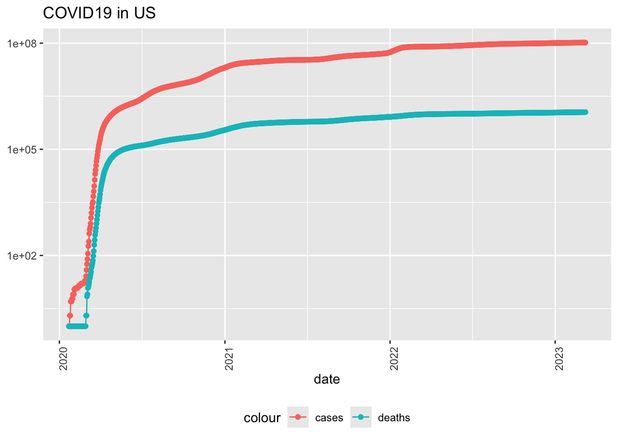

```r
US_totals %>%
  filter(cases > 0) %>%
  ggplot(aes(x = date, y = cases)) +
  geom_line(aes(color = "cases")) +
  geom_point(aes(color = "cases")) +
  geom_line(aes(y = deaths, color = "deaths")) +
  geom_point(aes(y = deaths, color = "deaths")) +
  scale_y_log10() +
  theme(legend.position="bottom",
        axis.text.x = element_text(angle = 90)) +
  labs(title = "COVID19 in US", y = NULL)
```

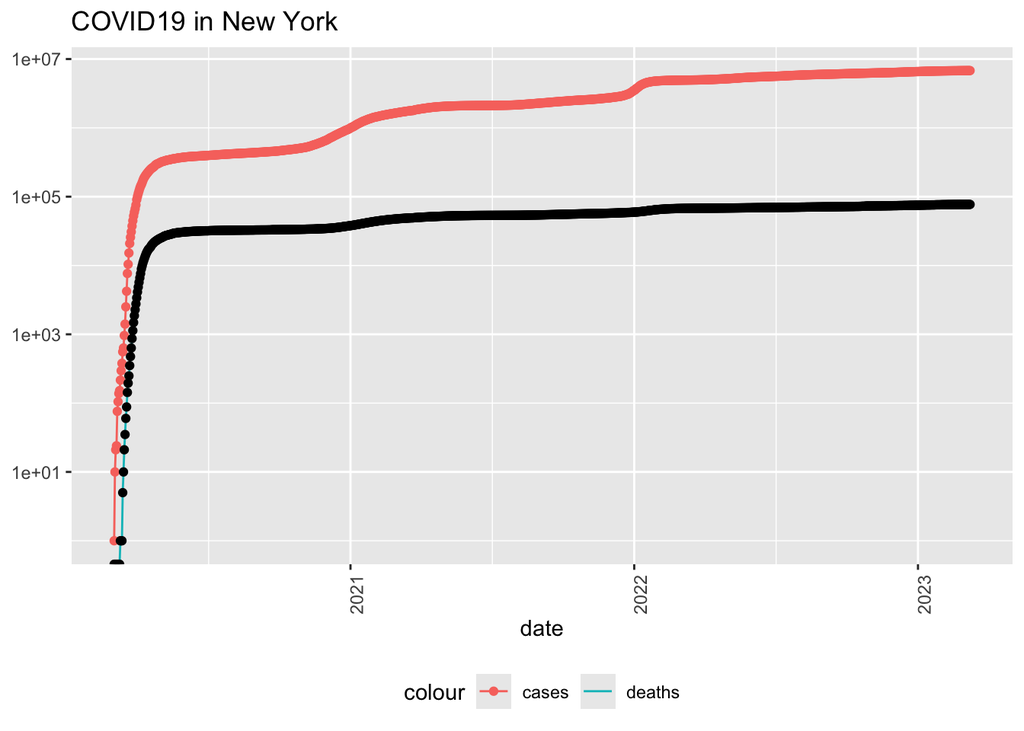

```r
state <- "New York"
US_by_state %>%
  filter(Province_State == state) %>%
  filter(cases > 0) %>%
  ggplot(aes(x = date, y =cases)) +
  geom_line(aes(color = "cases")) +
  geom_point(aes(color = "cases")) +
  geom_line(aes(y = deaths, color = "deaths")) +
  geom_point(aes(y = deaths, colors = "deaths")) +
  scale_y_log10() +
  theme(legend.position = "bottom",
        axis.text.x = element_text(angle = 90)) +
  labs(title = str_c("COVID19 in ", state), y = NULL)
```

```r
max(US_totals$date)
```

```
## [1] "2023-03-09"
```

```r
max(US_totals$deaths)
```

```
## [1] 1123836
```

```r
US_by_state <- US_by_state %>%
  mutate(new_cases = cases - lag(cases),
         new_deaths = deaths - lag(deaths))

US_totals <- US_totals %>%
  mutate(new_cases = cases - lag(cases),
         new_deaths = deaths - lag(deaths))

tail(US_totals %>% select(new_cases, new_deaths, everything()))
```

```
## # A tibble: 6 × 8
##   new_cases new_deaths Country_Region date          cases deaths deaths_per_mill
##       <dbl>      <dbl> <chr>          <date>        <dbl>  <dbl>           <dbl>
## 1      2147          7 US             2023-03-04   1.04e8 1.12e6           3371.
## 2     -3862        -38 US             2023-03-05   1.04e8 1.12e6           3371.
## 3      8564         47 US             2023-03-06   1.04e8 1.12e6           3371.
## 4     35371        335 US             2023-03-07   1.04e8 1.12e6           3372.
## 5     64861        730 US             2023-03-08   1.04e8 1.12e6           3374.
## 6     46931        590 US             2023-03-09   1.04e8 1.12e6           3376.
## # ℹ 1 more variable: Population <dbl>
```

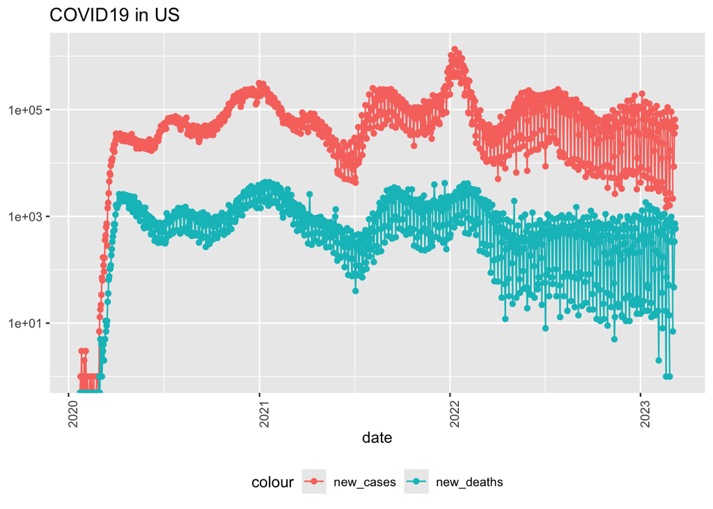

```r
US_totals %>%
  ggplot(aes(x = date, y = new_cases)) +
  geom_line(aes(color = "new_cases")) +
  geom_point(aes(color = "new_cases")) +
  geom_line(aes(y = new_deaths, color = "new_deaths")) +
  geom_point(aes(y = new_deaths, color = "new_deaths")) +
  scale_y_log10() +
  theme(legend.position="bottom",
        axis.text.x = element_text(angle = 90)) +
  labs(title = "COVID19 in US", y = NULL)
```

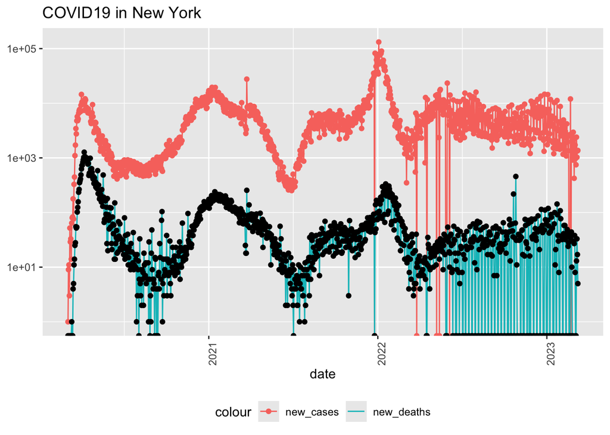

```r
state <- "New York"
US_by_state %>%
  filter(Province_State == state) %>%
  filter(cases > 0) %>%
  ggplot(aes(x = date, y = new_cases)) +
  geom_line(aes(color = "new_cases")) +
  geom_point(aes(color = "new_cases")) +
  geom_line(aes(y = new_deaths, color = "new_deaths")) +
  geom_point(aes(y = new_deaths, colors = "new_deaths")) +
  scale_y_log10() +
  theme(legend.position = "bottom",
        axis.text.x = element_text(angle = 90)) +
  labs(title = str_c("COVID19 in ", state), y = NULL)
```

```r
US_state_totals <- US_by_state %>%
  group_by(Province_State) %>%
  summarize(deaths = max (deaths), cases = max(cases),
            population = max(Population),
            cases_per_thou = 1000 * cases / population,
            deaths_per_thou = 1000 * deaths / population) %>%
  filter(cases > 0, population > 0)

US_state_totals %>%
  slice_min(deaths_per_thou, n = 10)
```

```
## # A tibble: 10 × 6
##    Province_State        deaths  cases population cases_per_thou deaths_per_thou
##    <chr>                  <dbl>  <dbl>      <dbl>          <dbl>           <dbl>
##  1 American Samoa            34 8.32e3      55641           150.           0.611
##  2 Northern Mariana Isl…     41 1.37e4      55144           248.           0.744
##  3 Virgin Islands           130 2.48e4     107268           231.           1.21
##  4 Hawaii                  1841 3.81e5    1415872           269.           1.30
##  5 Vermont                  929 1.53e5     623989           245.           1.49
##  6 Puerto Rico             5823 1.10e6    3754939           293.           1.55
##  7 Utah                    5298 1.09e6    3205958           340.           1.65
##  8 Alaska                  1486 3.08e5     740995           415.           2.01
##  9 District of Columbia    1432 1.78e5     705749           252.           2.03
## 10 Washington             15683 1.93e6    7614893           253.           2.06
```

```r
US_state_totals %>%
  slice_min(deaths_per_thou, n = 10) %>%
  select(deaths_per_thou, cases_per_thou, everything())
```

```
## # A tibble: 10 × 6
##    deaths_per_thou cases_per_thou Province_State        deaths  cases population
##              <dbl>          <dbl> <chr>                  <dbl>  <dbl>      <dbl>
##  1           0.611           150. American Samoa            34 8.32e3      55641
##  2           0.744           248. Northern Mariana Isl…     41 1.37e4      55144
##  3           1.21            231. Virgin Islands           130 2.48e4     107268
##  4           1.30            269. Hawaii                  1841 3.81e5    1415872
##  5           1.49            245. Vermont                  929 1.53e5     623989
##  6           1.55            293. Puerto Rico             5823 1.10e6    3754939
##  7           1.65            340. Utah                    5298 1.09e6    3205958
##  8           2.01            415. Alaska                  1486 3.08e5     740995
##  9           2.03            252. District of Columbia    1432 1.78e5     705749
## 10           2.06            253. Washington             15683 1.93e6    7614893
```

```r
US_state_totals %>%
  slice_max(deaths_per_thou, n = 10) %>%
  select(deaths_per_thou, cases_per_thou, everything())
```

```
## # A tibble: 10 × 6
##    deaths_per_thou cases_per_thou Province_State deaths   cases population
##              <dbl>          <dbl> <chr>           <dbl>   <dbl>      <dbl>
##  1            4.55           336. Arizona         33102 2443514    7278717
##  2            4.54           326. Oklahoma        17972 1290929    3956971
##  3            4.49           333. Mississippi     13370  990756    2976149
##  4            4.44           359. West Virginia    7960  642760    1792147
##  5            4.32           320. New Mexico       9061  670929    2096829
##  6            4.31           334. Arkansas        13020 1006883    3017804
##  7            4.29           335. Alabama         21032 1644533    4903185
##  8            4.28           368. Tennessee       29263 2515130    6829174
##  9            4.23           307. Michigan        42205 3064125    9986857
## 10            4.06           385. Kentucky        18130 1718471    4467673
```

```r
mod <- lm(deaths_per_thou ~ cases_per_thou, data = US_state_totals)
summary(mod)
```

```
##
## Call:
## lm(formula = deaths_per_thou ~ cases_per_thou, data = US_state_totals)
##
## Residuals:
##     Min      1Q  Median      3Q     Max
## -2.3352 -0.5978  0.1491  0.6535  1.2086
##
## Coefficients:
##                Estimate Std. Error t value Pr(>|t|)
## (Intercept)    -0.36167    0.72480  -0.499     0.62
## cases_per_thou  0.01133    0.00232   4.881 9.76e-06 ***
## ---
## Signif. codes:  0 '***' 0.001 '**' 0.01 '*' 0.05 '.' 0.1 ' ' 1
##
## Residual standard error: 0.8615 on 54 degrees of freedom
## Multiple R-squared:  0.3061, Adjusted R-squared:  0.2933
## F-statistic: 23.82 on 1 and 54 DF,  p-value: 9.763e-06
```

```r
US_state_totals %>% slice_min(cases_per_thou)
```

```
## # A tibble: 1 × 6
##   Province_State deaths cases population cases_per_thou deaths_per_thou
##   <chr>           <dbl> <dbl>      <dbl>          <dbl>           <dbl>
## 1 American Samoa     34  8320      55641           150.           0.611
```

```r
US_state_totals %>% slice_max(cases_per_thou)
```

```
## # A tibble: 1 × 6
##   Province_State deaths  cases population cases_per_thou deaths_per_thou
##   <chr>           <dbl>  <dbl>      <dbl>          <dbl>           <dbl>
## 1 Rhode Island     3870 460697    1059361           435.            3.65
```

```r
US_state_totals %>% mutate(pred = predict(mod))
```

```
## # A tibble: 56 × 7
##    Province_State  deaths  cases population cases_per_thou deaths_per_thou  pred
##    <chr>            <dbl>  <dbl>      <dbl>          <dbl>           <dbl> <dbl>
##  1 Alabama          21032 1.64e6    4903185           335.           4.29   3.44
##  2 Alaska            1486 3.08e5     740995           415.           2.01   4.34
##  3 American Samoa      34 8.32e3      55641           150.           0.611  1.33
##  4 Arizona          33102 2.44e6    7278717           336.           4.55   3.44
##  5 Arkansas         13020 1.01e6    3017804           334.           4.31   3.42
##  6 California      101159 1.21e7   39512223           307.           2.56   3.12
##  7 Colorado         14181 1.76e6    5758736           306.           2.46   3.11
##  8 Connecticut      12220 9.77e5    3565287           274.           3.43   2.74
##  9 Delaware          3324 3.31e5     973764           340.           3.41   3.49
## 10 District of Co…   1432 1.78e5     705749           252.           2.03   2.49
## # ℹ 46 more rows
```

```r
US_tot_w_pred <- US_state_totals %>% mutate(pred = predict(mod))
US_tot_w_pred
```

```
## # A tibble: 56 × 7
##    Province_State  deaths  cases population cases_per_thou deaths_per_thou  pred
##    <chr>            <dbl>  <dbl>      <dbl>          <dbl>           <dbl> <dbl>
##  1 Alabama          21032 1.64e6    4903185           335.           4.29   3.44
##  2 Alaska            1486 3.08e5     740995           415.           2.01   4.34
##  3 American Samoa      34 8.32e3      55641           150.           0.611  1.33
##  4 Arizona          33102 2.44e6    7278717           336.           4.55   3.44
##  5 Arkansas         13020 1.01e6    3017804           334.           4.31   3.42
##  6 California      101159 1.21e7   39512223           307.           2.56   3.12
##  7 Colorado         14181 1.76e6    5758736           306.           2.46   3.11
##  8 Connecticut      12220 9.77e5    3565287           274.           3.43   2.74
##  9 Delaware          3324 3.31e5     973764           340.           3.41   3.49
## 10 District of Co…   1432 1.78e5     705749           252.           2.03   2.49
## # ℹ 46 more rows
```

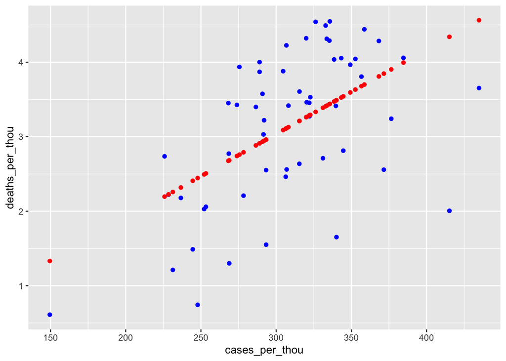

```r
US_tot_w_pred %>% ggplot() +
  geom_point(aes(x = cases_per_thou, y = deaths_per_thou), color = "blue") +
  geom_point(aes(x = cases_per_thou, y = pred), color = "red")
```

## Beyond the Lectures - Supplemental Analysis

### Cases_per_thou/deaths_per_thou and State Population

After working through the lectures and following along, the question I became focused on was how population affects cases and deaths. In the lectures we looked at the relationship between cases and deaths, but biggest driver of both would be how easily the disease was spread. Given that, there is likely a connection between both higher cases_per_thou and deaths_per_thou with state population.

Since state populations can vary greatly, with California having 39,512,223 residents compared to Wyoming’s 578,759, I will be applying a log10 scale to the population data to level the playing field so that states are compared fairly. This allows us to look at the impact of the percentage change in population on cases_per_thou and deaths_per_thou.

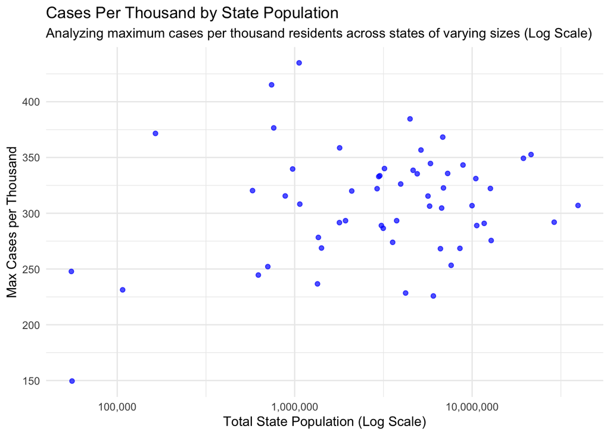

```r
# Graph cases/log10 population
ggplot(US_state_totals, aes(x = population, y = cases_per_thou)) +
  geom_point(alpha = 0.7, color = "blue") +
  scale_x_log10(labels = scales::comma) +
  labs(
    title = "Cases Per Thousand by State Population",
    subtitle = "Analyzing maximum cases per thousand residents across states of varying sizes (Log Scale)",
    x = "Total State Population (Log Scale)",
    y = "Max Cases per Thousand"
  ) +
  theme_minimal()
```

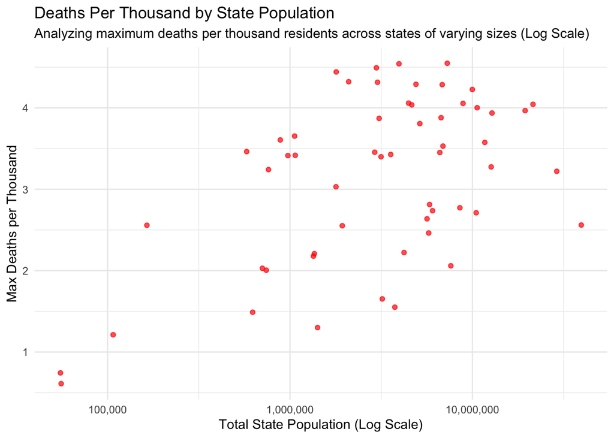

```r
# Graph deaths/log10 population
ggplot(US_state_totals, aes(x = population, y = deaths_per_thou)) +
  geom_point(alpha = 0.7, color = "red") +
  scale_x_log10(labels = scales::comma) +
  labs(
    title = "Deaths Per Thousand by State Population",
    subtitle = "Analyzing maximum deaths per thousand residents across states of varying sizes (Log Scale)",
    x = "Total State Population (Log Scale)",
    y = "Max Deaths per Thousand"
  ) +
  theme_minimal()
```

```r
# Create cases/log10 population model
pop_mod_cases <- lm(cases_per_thou ~ log10(population), data = US_state_totals)
summary(pop_mod_cases)
```

```
##
## Call:
## lm(formula = cases_per_thou ~ log10(population), data = US_state_totals)
##
## Residuals:
##      Min       1Q   Median       3Q      Max
## -126.952  -30.659    2.017   25.848  134.745
##
## Coefficients:
##                   Estimate Std. Error t value Pr(>|t|)
## (Intercept)         188.76      70.42   2.680  0.00973 **
## log10(population)    18.49      10.83   1.706  0.09372 .
## ---
## Signif. codes:  0 '***' 0.001 '**' 0.01 '*' 0.05 '.' 0.1 ' ' 1
##
## Residual standard error: 49.21 on 54 degrees of freedom
## Multiple R-squared:  0.05115,    Adjusted R-squared:  0.03358
## F-statistic: 2.911 on 1 and 54 DF,  p-value: 0.09372
```

```r
#Create deaths/log10 population model
pop_mod_deaths <- lm(deaths_per_thou ~ log10(population), data = US_state_totals)
summary(pop_mod_deaths)
```

```
##
## Call:
## lm(formula = deaths_per_thou ~ log10(population), data = US_state_totals)
##
## Residuals:
##     Min      1Q  Median      3Q     Max
## -1.6720 -0.6881  0.1288  0.7146  1.5042
##
## Coefficients:
##                   Estimate Std. Error t value Pr(>|t|)
## (Intercept)         -2.616      1.254  -2.085   0.0418 *
## log10(population)    0.888      0.193   4.602 2.58e-05 ***
## ---
## Signif. codes:  0 '***' 0.001 '**' 0.01 '*' 0.05 '.' 0.1 ' ' 1
##
## Residual standard error: 0.8765 on 54 degrees of freedom
## Multiple R-squared:  0.2817, Adjusted R-squared:  0.2684
## F-statistic: 21.18 on 1 and 54 DF,  p-value: 2.578e-05
```

As seen in both the graphs above, there does appear to be a relationship between population and both cases_per_thou and deaths_per_thou, but the model summaries show only one is significant. The model of cases_per_thou to population has a P-Value of 0.0937, which is above 0.05, and an R Squared of 0.051 meaning it only explains about 5% of the variance in case rates. The death_per_thou to population model is much better, with a P-Value of 2.578e-05 it is way below the 0.05 threshold, and an R Squared of 0.2817, meaning population scale explains about 28% of the variation in death rates.

These results go along with a major problem during the surges in the pandemic. At times, especially very early on, the volume of patients exceeded the capacity of our medical centers. That could mean more populated states were more likely to experience this problem, leading to higher death per case rates as they were unable to treat everyone, which could mean there is a connection between population and deaths per case in each state.

### Death Per Case Ratio and Population

```r
# Add the Death-to-Case Ratio
US_state_totals <- US_state_totals %>%
  mutate(death_per_case_ratio = deaths / cases)

# Create Death_Per_Case_Ratio Model
pop_dcratio_mod <- lm(death_per_case_ratio ~ log10(population), data = US_state_totals)
summary(pop_dcratio_mod)
```

```
##
## Call:
## lm(formula = death_per_case_ratio ~ log10(population), data = US_state_totals)
##
## Residuals:
##        Min         1Q     Median         3Q        Max
## -0.0052977 -0.0014082  0.0000928  0.0021556  0.0038433
##
## Coefficients:
##                     Estimate Std. Error t value Pr(>|t|)
## (Intercept)       -0.0073023  0.0034231  -2.133   0.0375 *
## log10(population)  0.0026835  0.0005267   5.095 4.57e-06 ***
## ---
## Signif. codes:  0 '***' 0.001 '**' 0.01 '*' 0.05 '.' 0.1 ' ' 1
##
## Residual standard error: 0.002392 on 54 degrees of freedom
## Multiple R-squared:  0.3247, Adjusted R-squared:  0.3122
## F-statistic: 25.96 on 1 and 54 DF,  p-value: 4.567e-06
```

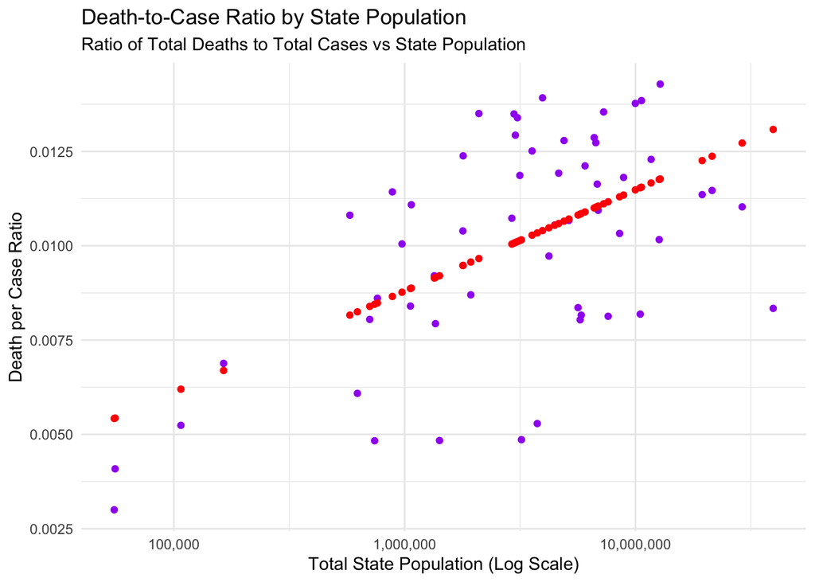

```r
# Add model to data set
US_tot_w_poppred <- US_state_totals %>% mutate(pred = predict(pop_dcratio_mod))

# Create graph with model plotted
US_tot_w_poppred %>% ggplot() +
  geom_point(aes(x = population, y = death_per_case_ratio), color = "purple") +
  geom_point(aes(x = population, y = pred), color = "red") +
  scale_x_log10(labels = scales::comma) +
  labs(
    title = "Death-to-Case Ratio by State Population",
    subtitle = "Ratio of Total Deaths to Total Cases vs State Population",
    x = "Total State Population (Log Scale)",
    y = "Death per Case Ratio"
  ) +
  theme_minimal()
```

As seen in the model summary and graph above, the relationship between deaths per case and population is even more significant. With a P-Value of 4.567e-06 and an R Squared of 0.3247, this is the strongest model yet.

### Potential Bias

In terms of the supplemental data analysis I’ve done, one source of bias could be that I grew up just outside of Washington, DC and was in that area during the majority of the pandemic, so I experienced the impact being in a larger population could have, especially in such a densely populated area.

With regards to the actual analysis, state population can also be the smoke as opposed to the fire, by that I mean that while population clearly has an impact, the relationship may be better explained by what I just mentioned: population density.